# R_Cyclistic_Business_Full_Year_Analysis

Michael

2021/9/22

# 1. Project Backgroud and working environment setting

## Project background introduction

Cyclistic bike-share analysis is a frictional case study organized by Google Data Analytics capstone project team. In the project hypothesis, the marketing director of Cyclistic company, that is Lily Moreno, what to design a marketing strategy for converting casual riders to annual members to reinforce company’s future. The marketing strategy should answer the following questions.

1. How do annual members and casual riders use Cyclistic bikes differently?
2. Why would casual riders buy Cyclistic annual memberships?
3. How can Cyclistic use digital media to influence casual riders to become members?

This section analysis is trying to answer the first question, finding behavior insights or patterns between two type customers.

## Data resources and ROCCC inspect

1. Cyclistic is a fictional company for the purposes of this case study.
2. The data has been made available by Motivate International Inc. under [this license](https://www.divvybikes.com/data-license-agreement)
3. The data was downloaded from amazonaws website [link](https://divvy-tripdata.s3.amazonaws.com/index.html).
4. As case study statement required, downloaded previous 12 months data, that’s from Sep 2020 to Aug 2021.

## Install required packages and other environments setting.

```
## [1] "English_United States.1252"
```

# 2. Inspecting monthly Data

## Ispecting data of August 2021.

```r
setwd("D:/resume_portfolio/cyclistic_google_case1/divvy_tripdata")
m8_2021 <-read_csv('202108-divvy-tripdata.csv')  #Rows: 804352 Columns: 13
colnames(m8_2021)
```

```
##  [1] "ride_id"            "rideable_type"      "started_at"
##  [4] "ended_at"           "start_station_name" "start_station_id"
##  [7] "end_station_name"   "end_station_id"     "start_lat"
## [10] "start_lng"          "end_lat"            "end_lng"
## [13] "member_casual"
```

```r
str(m8_2021)
```

```
## spec_tbl_df [804,352 x 13] (S3: spec_tbl_df/tbl_df/tbl/data.frame)
##  $ ride_id           : chr [1:804352] "99103BB87CC6C1BB" "EAFCCCFB0A3FC5A1" "9EF4F46C57AD234D" "5834D3208BFAF1DA" ...
##  $ rideable_type     : chr [1:804352] "electric_bike" "electric_bike" "electric_bike" "electric_bike" ...
##  $ started_at        : POSIXct[1:804352], format: "2021-08-10 17:15:49" "2021-08-10 17:23:14" ...
##  $ ended_at          : POSIXct[1:804352], format: "2021-08-10 17:22:44" "2021-08-10 17:39:24" ...
##  $ start_station_name: chr [1:804352] NA NA NA NA ...
##  $ start_station_id  : chr [1:804352] NA NA NA NA ...
##  $ end_station_name  : chr [1:804352] NA NA NA NA ...
##  $ end_station_id    : chr [1:804352] NA NA NA NA ...
##  $ start_lat         : num [1:804352] 41.8 41.8 42 42 41.8 ...
##  $ start_lng         : num [1:804352] -87.7 -87.7 -87.7 -87.7 -87.6 ...
##  $ end_lat           : num [1:804352] 41.8 41.8 42 42 41.8 ...
##  $ end_lng           : num [1:804352] -87.7 -87.6 -87.7 -87.7 -87.6 ...
##  $ member_casual     : chr [1:804352] "member" "member" "member" "member" ...
##  - attr(*, "spec")=
##   .. cols(
##   ..   ride_id = col_character(),
##   ..   rideable_type = col_character(),
##   ..   started_at = col_datetime(format = ""),
##   ..   ended_at = col_datetime(format = ""),
##   ..   start_station_name = col_character(),
##   ..   start_station_id = col_character(),
##   ..   end_station_name = col_character(),
##   ..   end_station_id = col_character(),
##   ..   start_lat = col_double(),
##   ..   start_lng = col_double(),
##   ..   end_lat = col_double(),
##   ..   end_lng = col_double(),
##   ..   member_casual = col_character()
##   .. )
##  - attr(*, "problems")=<externalptr>
```

## Uploading other 11 months’ data.

## Problem solving:

1. start_station_id and end_station_id have different datatype from previous months. November, October and September of 2020

# 3. Stack and inspect, process Data

### Stack individual month’s data frames into whole year data frame. And delete unnecessary features.

```
## # A tibble: 6 x 9
##   ride_id          rideable_type started_at          ended_at            start_station_n~
##   <chr>            <chr>         <dttm>              <dttm>              <chr>
## 1 99103BB87CC6C1BB electric_bike 2021-08-10 17:15:49 2021-08-10 17:22:44 <NA>
## 2 EAFCCCFB0A3FC5A1 electric_bike 2021-08-10 17:23:14 2021-08-10 17:39:24 <NA>
## 3 9EF4F46C57AD234D electric_bike 2021-08-21 02:34:23 2021-08-21 02:50:36 <NA>
## 4 5834D3208BFAF1DA electric_bike 2021-08-21 06:52:55 2021-08-21 07:08:13 <NA>
## 5 CD825CB87ED1D096 electric_bike 2021-08-19 11:55:29 2021-08-19 12:04:11 <NA>
## 6 612F12C94A964F3E electric_bike 2021-08-19 12:41:12 2021-08-19 12:47:47 <NA>
## # ... with 4 more variables: start_station_id <chr>, end_station_name <chr>,
## #   end_station_id <chr>, member_casual <chr>
```

### Inspect new table, Summary for numeric and datetime columns

```
## [1] "ride_id"            "rideable_type"      "started_at"
## [4] "ended_at"           "start_station_name" "start_station_id"
## [7] "end_station_name"   "end_station_id"     "member_casual"
```

```
## [1] 4913072
```

```
## [1] 4913072       9
```

```
## # A tibble: 6 x 9
##   ride_id          rideable_type started_at          ended_at            start_station_n~
##   <chr>            <chr>         <dttm>              <dttm>              <chr>
## 1 99103BB87CC6C1BB electric_bike 2021-08-10 17:15:49 2021-08-10 17:22:44 <NA>
## 2 EAFCCCFB0A3FC5A1 electric_bike 2021-08-10 17:23:14 2021-08-10 17:39:24 <NA>
## 3 9EF4F46C57AD234D electric_bike 2021-08-21 02:34:23 2021-08-21 02:50:36 <NA>
## 4 5834D3208BFAF1DA electric_bike 2021-08-21 06:52:55 2021-08-21 07:08:13 <NA>
## 5 CD825CB87ED1D096 electric_bike 2021-08-19 11:55:29 2021-08-19 12:04:11 <NA>
## 6 612F12C94A964F3E electric_bike 2021-08-19 12:41:12 2021-08-19 12:47:47 <NA>
## # ... with 4 more variables: start_station_id <chr>, end_station_name <chr>,
## #   end_station_id <chr>, member_casual <chr>
```

```
## tibble [4,913,072 x 9] (S3: tbl_df/tbl/data.frame)
##  $ ride_id           : chr [1:4913072] "99103BB87CC6C1BB" "EAFCCCFB0A3FC5A1" "9EF4F46C57AD234D" "5834D3208BFAF1DA" ...
##  $ rideable_type     : chr [1:4913072] "electric_bike" "electric_bike" "electric_bike" "electric_bike" ...
##  $ started_at        : POSIXct[1:4913072], format: "2021-08-10 17:15:49" "2021-08-10 17:23:14" ...
##  $ ended_at          : POSIXct[1:4913072], format: "2021-08-10 17:22:44" "2021-08-10 17:39:24" ...
##  $ start_station_name: chr [1:4913072] NA NA NA NA ...
##  $ start_station_id  : chr [1:4913072] NA NA NA NA ...
##  $ end_station_name  : chr [1:4913072] NA NA NA NA ...
##  $ end_station_id    : chr [1:4913072] NA NA NA NA ...
##  $ member_casual     : chr [1:4913072] "member" "member" "member" "member" ...
```

```
##    ride_id          rideable_type        started_at
##  Length:4913072     Length:4913072     Min.   :2020-09-01 00:00:07
##  Class :character   Class :character   1st Qu.:2020-12-09 18:57:27
##  Mode  :character   Mode  :character   Median :2021-05-26 16:51:05
##                                        Mean   :2021-04-11 06:27:48
##                                        3rd Qu.:2021-07-17 03:36:04
##                                        Max.   :2021-08-31 23:59:35
##     ended_at                   start_station_name start_station_id
##  Min.   :2020-09-01 00:04:43   Length:4913072     Length:4913072
##  1st Qu.:2020-12-09 18:29:54   Class :character   Class :character
##  Median :2021-05-26 17:12:45   Mode  :character   Mode  :character
##  Mean   :2021-04-11 06:48:57
##  3rd Qu.:2021-07-17 04:16:25
##  Max.   :2021-09-01 17:37:35
##  end_station_name   end_station_id     member_casual
##  Length:4913072     Length:4913072     Length:4913072
##  Class :character   Class :character   Class :character
##  Mode  :character   Mode  :character   Mode  :character
##
##
##
```

### Character columns: More detailed information

```
## [1] 4912863
```

```
## [1] "electric_bike" "classic_bike"  "docked_bike"
```

```
##
##  casual  member
## 2225089 2687983
```

```
## [1] 758
```

```
## [1] 1294
```

```
## [1] 757
```

```
## [1] 1294
```

### check missing values for each columns

```
## [1] "start_station_name" "450045"
## [1] "start_station_id" "450571"
## [1] "end_station_name" "491380"
## [1] "end_station_id" "491764"
```

results 1. “start_station_name” “450045” NA  
2. “start_station_id” “450571” NA  
3. “end_station_name” “491380” NA  
4. “end_station_id” “491764” NA

### Increase columns for better presenting data. trip_duration, year, month, day, weekday

increase duration and change datatype

```r
trips_y$trip_duration <- difftime(trips_y$ended_at, trips_y$started_at)

trips_y$trip_duration <- as.numeric(as.character(trips_y$trip_duration))
```

### Delete records which hold invalid value in trip_duration column.

```r
trips_y2 <- trips_y[trips_y$trip_duration >= 0,]
```

# 4. Conduct data analysis and create visuals.

### 01 Business increase during the last 12 months.

conclusion: Casual users increased faster than membership users during the previous 12 months.

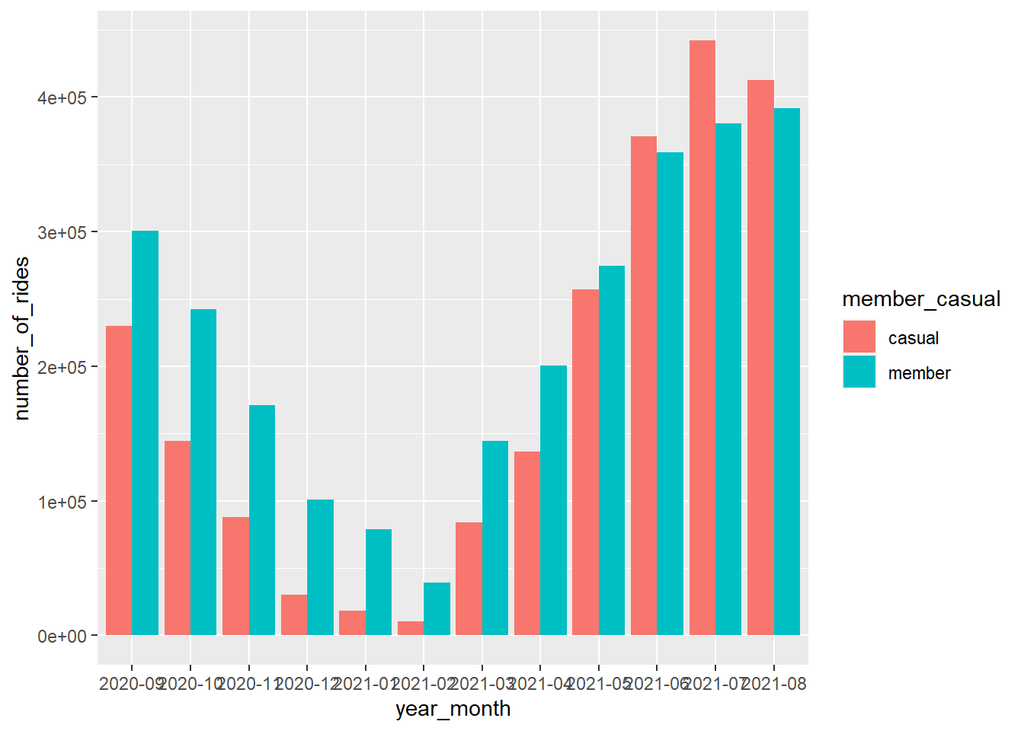

```r
trips_y2$year_month <- format(trips_y2$started_at,"%Y-%m")

trips_y2 %>%
  group_by(member_casual, year_month) %>%
  summarise(number_of_rides = n(), average_duration = mean(trip_duration)) %>%
  arrange(member_casual,year_month) %>%
  ggplot(aes(x=year_month, y=number_of_rides, fill=member_casual)) +
  geom_col(position='dodge')
```

### 02 The number of rides vs weekday and rider types

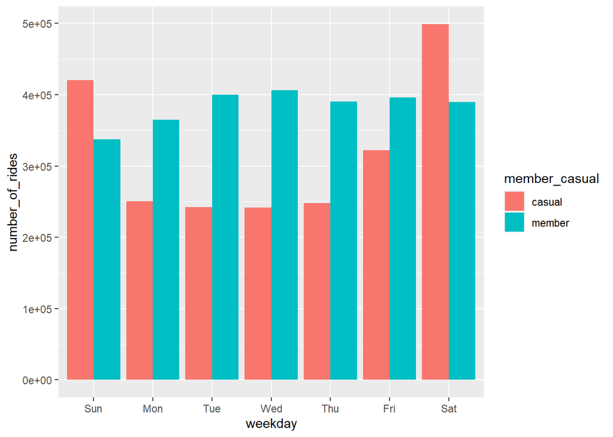

```r
trips_y2 %>%
  mutate(weekday = wday(trips_y2$started_at, label = TRUE)) %>%    #increase a column, get weekday
  group_by(member_casual, weekday) %>%
  summarise(number_of_rides = n(), average_duration = mean(trip_duration)) %>%  #calculates number of rides
  arrange(member_casual,weekday) %>%
  ggplot(aes(x=weekday, y=number_of_rides, fill=member_casual)) +
  geom_col(position='dodge')
```